# Exploratory Data Analysis

#### Libraries

```r
library(tidyverse, quietly = TRUE)
library(skimr, quietly = TRUE)
library(statsr, quietly = TRUE)
library(GGally, quietly = TRUE)
library(corrplot, quietly = TRUE)
```

Dataset: https://github.com/fivethirtyeight/data/tree/master/college-majors

| Header | Description |
| --- | --- |
| `Rank` | Rank by median earnings |
| `Major_code` | Major code, FO1DP in ACS PUMS |
| `Major` | Major description |
| `Major_category` | Category of major from Carnevale et al |
| `Total` | Total number of people with major |
| `Sample_size` | Sample size (unweighted) of full-time, year-round ONLY (used for earnings) |
| `Men` | Male graduates |
| `Women` | Female graduates |
| `ShareWomen` | Women as share of total |
| `Employed` | Number employed (ESR == 1 or 2) |
| `Full_time` | Employed 35 hours or more |
| `Part_time` | Employed less than 35 hours |
| `Full_time_year_round` | Employed at least 50 weeks (WKW == 1) and at least 35 hours (WKHP >= 35) |
| `Unemployed` | Number unemployed (ESR == 3) |
| `Unemployment_rate` | Unemployed / (Unemployed + Employed) |
| `Median` | Median earnings of full-time, year-round workers |
| `P25th` | 25th percentile of earnings |
| `P75th` | 75th percentile of earnings |
| `College_jobs` | Number with job requiring a college degree |
| `Non_college_jobs` | Number with job not requiring a college degree |
| `Low_wage_jobs` | Number in low-wage service jobs |

The intent of this section is to go over a practical project, following the steps: loading the dataset, understanding the data, treating missing values, exploring and visualizing, and the analysis report.

# 1 Loading the dataset

To continue we need the libraries mentioned before:

- `tidyverse` : eight libraries included, to work with data
- `skimr` : descriptive statistics
- `statsr` : statistical tools and data sampling
- `GGally` : for pair plots
- `corrplot` : correlation plots

```r
# Reading a csv from a web
url <- "https://raw.githubusercontent.com/fivethirtyeight/data/master/college-majors/recent-grads.csv"

df <- read_csv(url)
df.original <- df
```

We’ll keep a copy of the original data frame just in case we need to recover some columns or for comparison reasons.

# 2 Understanding the data

Let’s check the firsts observations:

```r
df %>%
    head()
```

| Rank | Major_code | Major | Total | Men | Women | Major_category | ShareWomen | Sample_size | Employed | Full_time | Part_time | Full_time_year_round | Unemployed | Unemployment_rate | Median | P25th | P75th | College_jobs | Non_college_jobs | Low_wage_jobs |
| --- | --- | --- | --- | --- | --- | --- | --- | --- | --- | --- | --- | --- | --- | --- | --- | --- | --- | --- | --- | --- |
| 1 | 2419 | PETROLEUM ENGINEERING | 2339 | 2057 | 282 | Engineering | 0.1206 | 36 | 1976 | 1849 | 270 | 1207 | 37 | 0.01838 | 110000 | 95000 | 125000 | 1534 | 364 | 193 |
| 2 | 2416 | MINING AND MINERAL ENGINEERING | 756 | 679 | 77 | Engineering | 0.1019 | 7 | 640 | 556 | 170 | 388 | 85 | 0.11724 | 75000 | 55000 | 90000 | 350 | 257 | 50 |
| 3 | 2415 | METALLURGICAL ENGINEERING | 856 | 725 | 131 | Engineering | 0.1530 | 3 | 648 | 558 | 133 | 340 | 16 | 0.02410 | 73000 | 50000 | 105000 | 456 | 176 | 0 |
| 4 | 2417 | NAVAL ARCHITECTURE AND MARINE ENGINEERING | 1258 | 1123 | 135 | Engineering | 0.1073 | 16 | 758 | 1069 | 150 | 692 | 40 | 0.05013 | 70000 | 43000 | 80000 | 529 | 102 | 0 |
| 5 | 2405 | CHEMICAL ENGINEERING | 32260 | 21239 | 11021 | Engineering | 0.3416 | 289 | 25694 | 23170 | 5180 | 16697 | 1672 | 0.06110 | 65000 | 50000 | 75000 | 18314 | 4440 | 972 |
| 6 | 2418 | NUCLEAR ENGINEERING | 2573 | 2200 | 373 | Engineering | 0.1450 | 17 | 1857 | 2038 | 264 | 1449 | 400 | 0.17723 | 65000 | 50000 | 102000 | 1142 | 657 | 244 |

We can see that the data is **rectangular**. At first we do not see any problems with language encoding (strange symbols). And the CSV was read correctly because the columns are fine delimited.

- `glimpse()`: similar to `str()`, returns the columns, types and some values.

```r
glimpse(df)
```

```
Rows: 173
Columns: 21
$ Rank                 <dbl> 1, 2, 3, 4, 5, 6, 7, 8, 9, 10, 11, 12, 13, 14, 15, 16, 17, 18, 19, 20…
$ Major_code           <dbl> 2419, 2416, 2415, 2417, 2405, 2418, 6202, 5001, 2414, 2408, 2407, 240…
$ Major                <chr> "PETROLEUM ENGINEERING", "MINING AND MINERAL ENGINEERING", "METALLURG…
$ Total                <dbl> 2339, 756, 856, 1258, 32260, 2573, 3777, 1792, 91227, 81527, 41542, 1…
$ Men                  <dbl> 2057, 679, 725, 1123, 21239, 2200, 2110, 832, 80320, 65511, 33258, 12…
$ Women                <dbl> 282, 77, 131, 135, 11021, 373, 1667, 960, 10907, 16016, 8284, 2105, 6…
$ Major_category       <chr> "Engineering", "Engineering", "Engineering", "Engineering", "Engineer…
$ ShareWomen           <dbl> 0.12056434, 0.10185185, 0.15303738, 0.10731320, 0.34163050, 0.1449669…
$ Sample_size          <dbl> 36, 7, 3, 16, 289, 17, 51, 10, 1029, 631, 399, 147, 79, 22, 30, 55, 1…
$ Employed             <dbl> 1976, 640, 648, 758, 25694, 1857, 2912, 1526, 76442, 61928, 32506, 11…
$ Full_time            <dbl> 1849, 556, 558, 1069, 23170, 2038, 2924, 1085, 71298, 55450, 30315, 1…
$ Part_time            <dbl> 270, 170, 133, 150, 5180, 264, 296, 553, 13101, 12695, 5146, 2724, 26…
$ Full_time_year_round <dbl> 1207, 388, 340, 692, 16697, 1449, 2482, 827, 54639, 41413, 23621, 879…
$ Unemployed           <dbl> 37, 85, 16, 40, 1672, 400, 308, 33, 4650, 3895, 2275, 794, 1019, 78, …
$ Unemployment_rate    <dbl> 0.018380527, 0.117241379, 0.024096386, 0.050125313, 0.061097712, 0.17…
$ Median               <dbl> 110000, 75000, 73000, 70000, 65000, 65000, 62000, 62000, 60000, 60000…
$ P25th                <dbl> 95000, 55000, 50000, 43000, 50000, 50000, 53000, 31500, 48000, 45000,…
$ P75th                <dbl> 125000, 90000, 105000, 80000, 75000, 102000, 72000, 109000, 70000, 72…
$ College_jobs         <dbl> 1534, 350, 456, 529, 18314, 1142, 1768, 972, 52844, 45829, 23694, 818…
$ Non_college_jobs     <dbl> 364, 257, 176, 102, 4440, 657, 314, 500, 16384, 10874, 5721, 2425, 24…
$ Low_wage_jobs        <dbl> 193, 50, 0, 0, 972, 244, 259, 220, 3253, 3170, 980, 372, 789, 81, 263…
```

Looking the previous output we can see two character columns (Mayor, Mayor_category), this columns will be factor but also ‘Major_code’ which is an identification. We can keep all three as character to avoid problems with data handling, or we could work with factors taking care about this.

```r
cols.factor <- c("Major", "Major_code", "Major_category")

df <- df %>%
    mutate_at(cols.factor, factor)
```

Before to start with descriptive statistics let’s disable scientific notations and establishing 4 decimals.

```r
options(scipen=999, digits=4)
```

- `skim()`: returns a summary table for the given data frame

Lets store the skim table in an object and calculate manually the coefficient of variation for the variables:

```r
stats <- skim(df)
stats$numeric.sd / stats$numeric.mean
```

```
 [1]     NA     NA     NA 0.5757 1.6125 1.6816 1.8130 0.4427 1.7366 1.6246 1.6470 1.6585 1.6838
[14] 1.7021 0.4448 0.2857 0.3107 0.2895 1.7285 1.7908 1.7997
```

```r
# The returned NA values are the character/factor variables
```

- CV close to 0: there is a little variability in the data which is around the mean.
- CV between 0 and 1: moderate variability. Closer to 1 the greater dispersion.
- CV close to 2: high variability suggesting highly dispersion. The mean may not be a reliable representation.

```r
# Descriptive statistics

skim(df)
```

```
── Data Summary ────────────────────────
                           Values
Name                       df
Number of rows             173
Number of columns          21
_______________________
Column type frequency:
  factor                   3
  numeric                  18
________________________
Group variables            None
```

|  | skim_variable | n_missing | complete_rate | ordered | n_unique | top_counts |
| --- | --- | --- | --- | --- | --- | --- |
| 1 | Major_code | 0 | 1 | FALSE | 173 | 110: 1, 110: 1, 110: 1, 110: 1 |
| 2 | Major | 0 | 1 | FALSE | 173 | ACC: 1, ACT: 1, ADV: 1, AER: 1 |
| 3 | Major_category | 0 | 1 | FALSE | 16 | Eng: 29, Edu: 16, Hum: 15, Bio: 14 |

|  | skim_variable | n_missing | complete_rate | mean | sd | p0 | p25 | p50 | p75 | p100 | hist |
| --- | --- | --- | --- | --- | --- | --- | --- | --- | --- | --- | --- |
| 1 | Rank | 0 | 1.0000 | 87.00000 | 50.08493 | 1 | 44.00000 | 87.00000 | 130.00000 | 173.0000 | ▇▇▇▇▇ |
| 2 | Total | 1 | 0.9942 | 39370.08140 | 63483.49101 | 124 | 4549.75000 | 15104.00000 | 38909.75000 | 393735.0000 | ▇▁▁▁▁ |
| 3 | Men | 1 | 0.9942 | 16723.40698 | 28122.43347 | 119 | 2177.50000 | 5434.00000 | 14631.00000 | 173809.0000 | ▇▁▁▁▁ |
| 4 | Women | 1 | 0.9942 | 22646.67442 | 41057.33074 | 0 | 1778.25000 | 8386.50000 | 22553.75000 | 307087.0000 | ▇▁▁▁▁ |
| 5 | ShareWomen | 1 | 0.9942 | 0.52222 | 0.23120 | 0 | 0.33603 | 0.53402 | 0.70330 | 0.9690 | ▂▆▆▇▃ |
| 6 | Sample_size | 0 | 1.0000 | 356.08092 | 618.36102 | 2 | 39.00000 | 130.00000 | 338.00000 | 4212.0000 | ▇▁▁▁▁ |
| 7 | Employed | 0 | 1.0000 | 31192.76301 | 50675.00224 | 0 | 3608.00000 | 11797.00000 | 31433.00000 | 307933.0000 | ▇▁▁▁▁ |
| 8 | Full_time | 0 | 1.0000 | 26029.30636 | 42869.65509 | 111 | 3154.00000 | 10048.00000 | 25147.00000 | 251540.0000 | ▇▁▁▁▁ |
| 9 | Part_time | 0 | 1.0000 | 8832.39884 | 14648.17947 | 0 | 1030.00000 | 3299.00000 | 9948.00000 | 115172.0000 | ▇▁▁▁▁ |
| 10 | Full_time_year_round | 0 | 1.0000 | 19694.42775 | 33160.94151 | 111 | 2453.00000 | 7413.00000 | 16891.00000 | 199897.0000 | ▇▁▁▁▁ |

[output cut: 8 more lines]

We can see the is a missing value in four variables, we need to know if it is the same observation. Also, there are more women than men and more people employed than unemployed. The jobs requiring a college degree are balanced with the jobs which no require a degree. Looking the Coefficient of Variation, almost every variable have a high value, greater than 1, which suggest high dispersion; and a very few variables have 0.3 or less which suggest the data is around the mean on this variables.

# 3 Treating missing data

The missing values also have meaning, could be a human mistake or an omitted response of the user.

```r
df[which(is.na(df$Total)),]
```

| Rank | Major_code | Major | Total | Men | Women | Major_category | ShareWomen | Sample_size | Employed | Full_time | Part_time | Full_time_year_round | Unemployed | Unemployment_rate | Median | P25th | P75th | College_jobs | Non_college_jobs | Low_wage_jobs |
| --- | --- | --- | --- | --- | --- | --- | --- | --- | --- | --- | --- | --- | --- | --- | --- | --- | --- | --- | --- | --- |
| 22 | 1104 | FOOD SCIENCE | NA | NA | NA | Agriculture & Natural Resources | NA | 36 | 3149 | 2558 | 1121 | 1735 | 338 | 0.09693 | 53000 | 32000 | 70000 | 1183 | 1274 | 485 |

Since there is only one observation we can drop it because represent less than 1%. It is recommended to use other treatment if missing values are greater than 5% of the observations.

```r
df.clean <- df %>% drop_na()

dim(df.clean)
```

```
[1] 172  21
```

# 4 Exploring and visualizing the data

Here we are going to create some questions to lead the exploration.

## 4.1 Univariate Analysis

It is to look one variable at a time. Let’s graph some histograms of the numeric variables with a *for* loop.

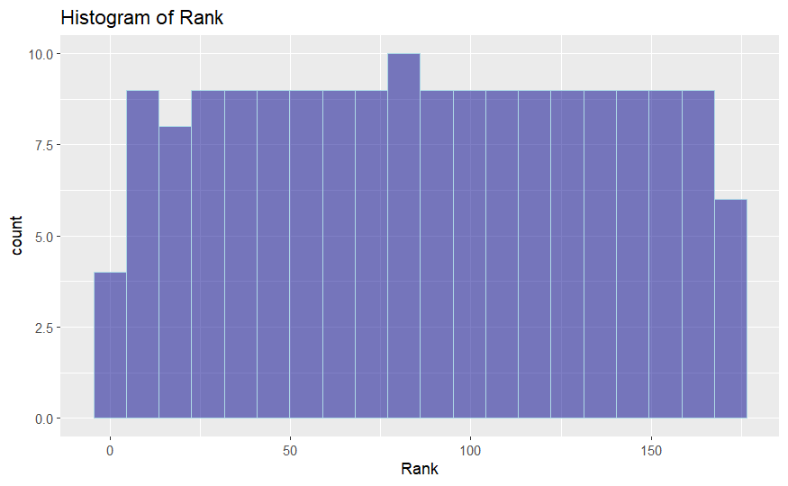

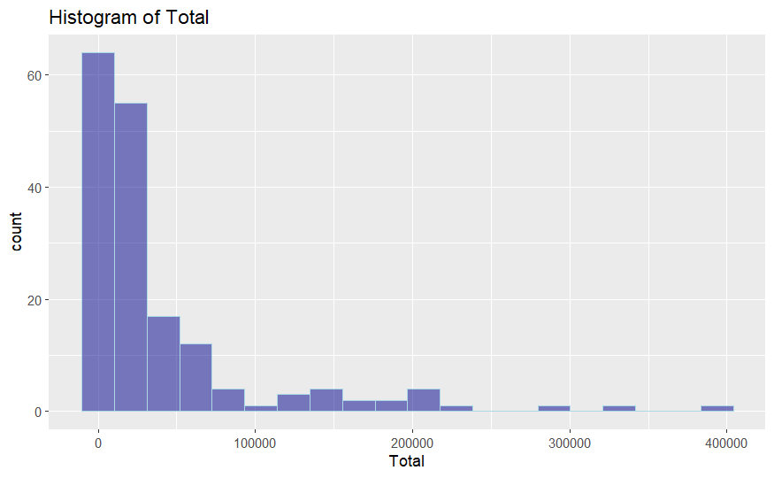

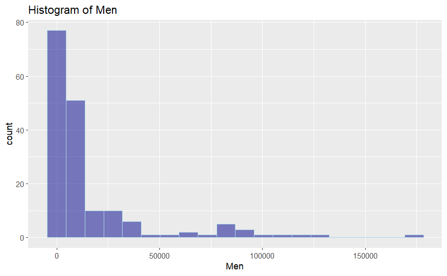

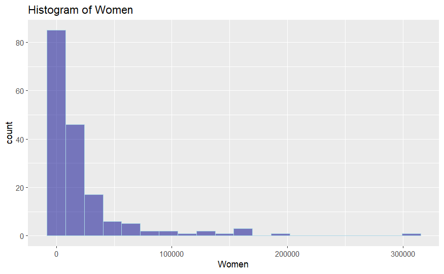

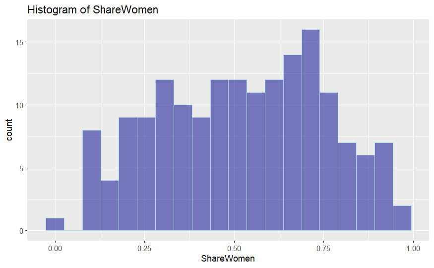

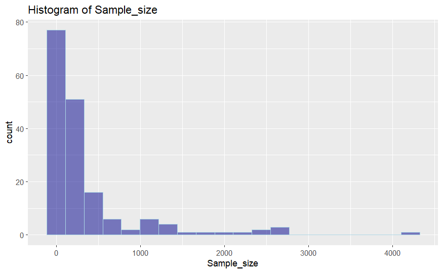

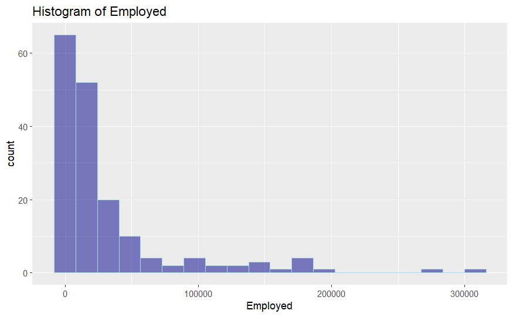

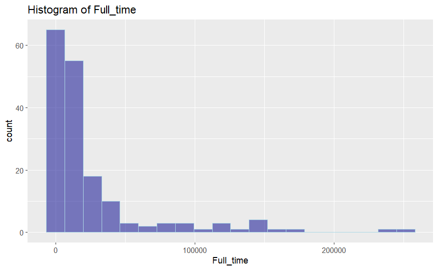

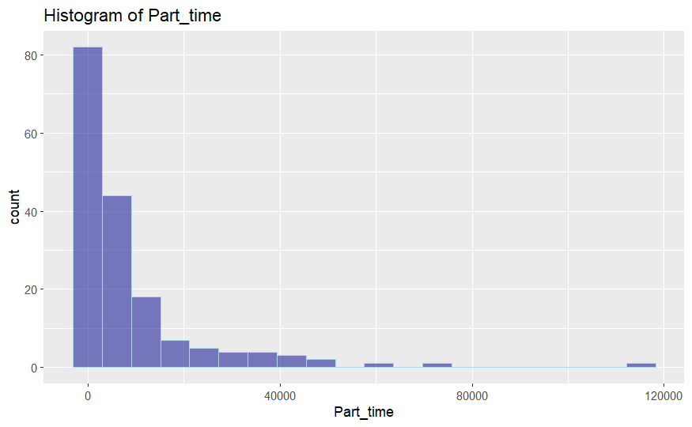

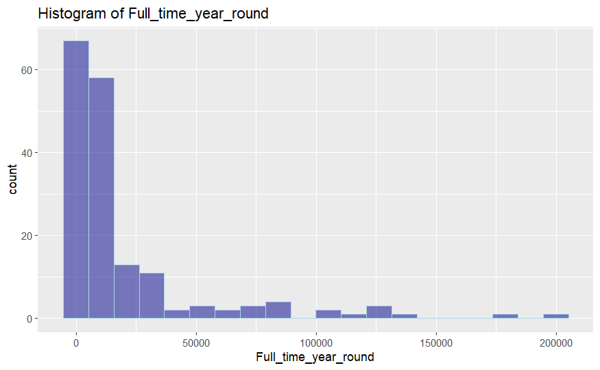

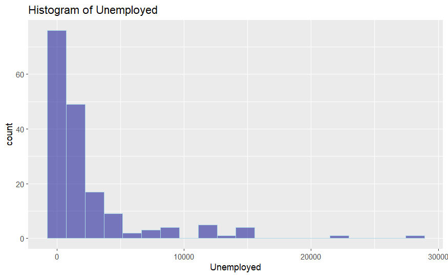

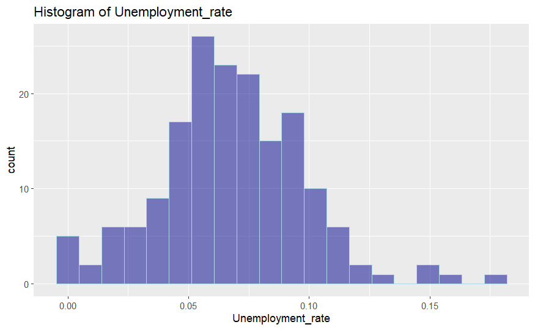

[6 more figures not shown]

```r
for (var in colnames(select_if(df.clean, is.numeric)) ) {
    g = ggplot(df.clean) +
        geom_histogram( aes( unlist(df.clean[, var]) ), bins=20,
                        fill = "darkblue", color = "lightblue", alpha = 0.5) +
        labs( title = paste("Histogram of", var),
              x = var)
    plot(g)
}
```

And to be able to see outliers the boxplot will be our aproach.

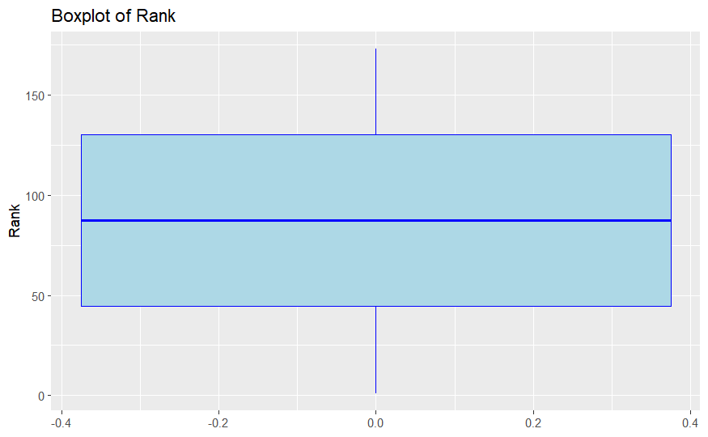

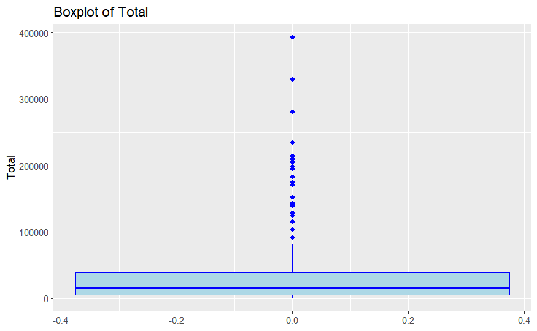

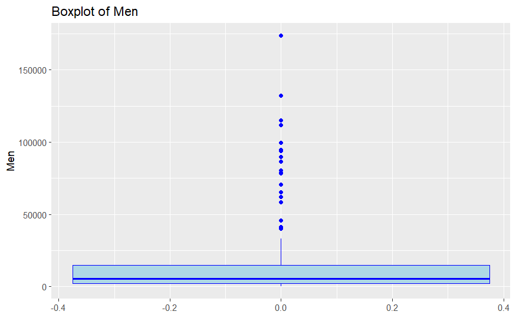

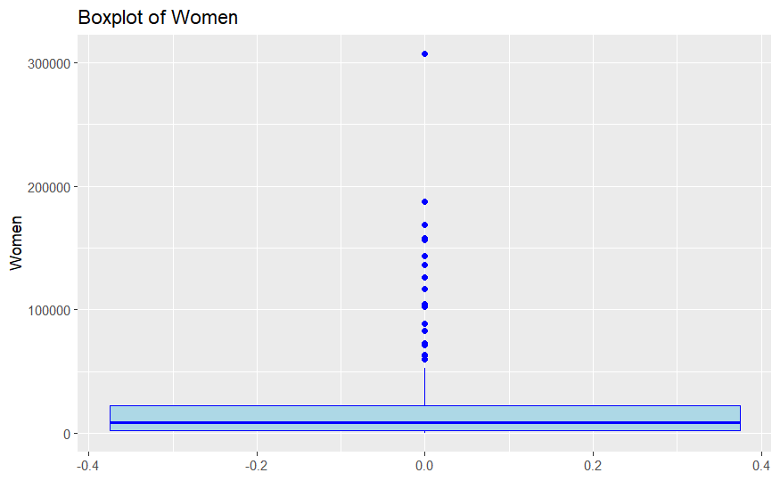

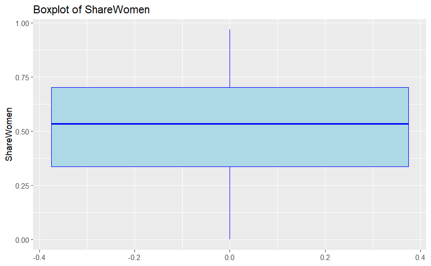

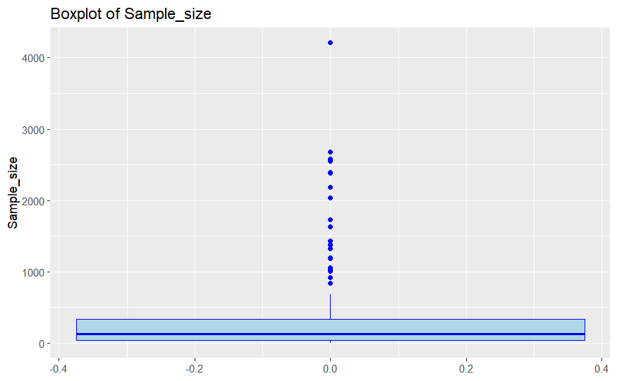

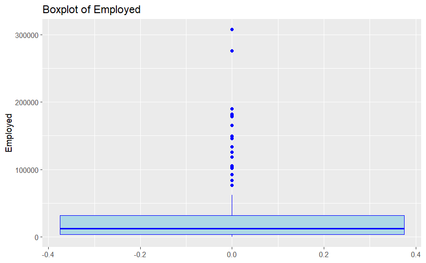

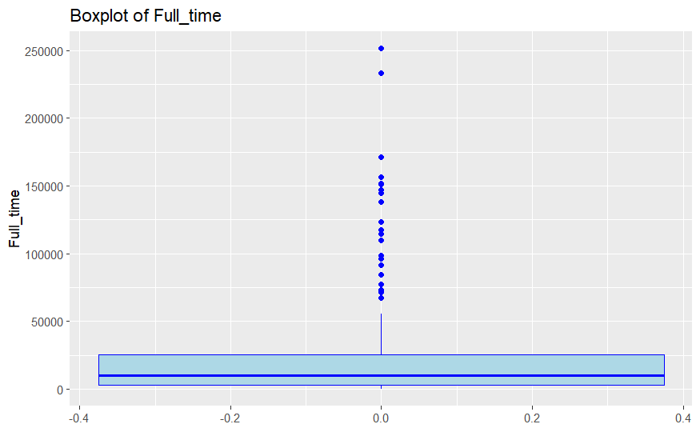

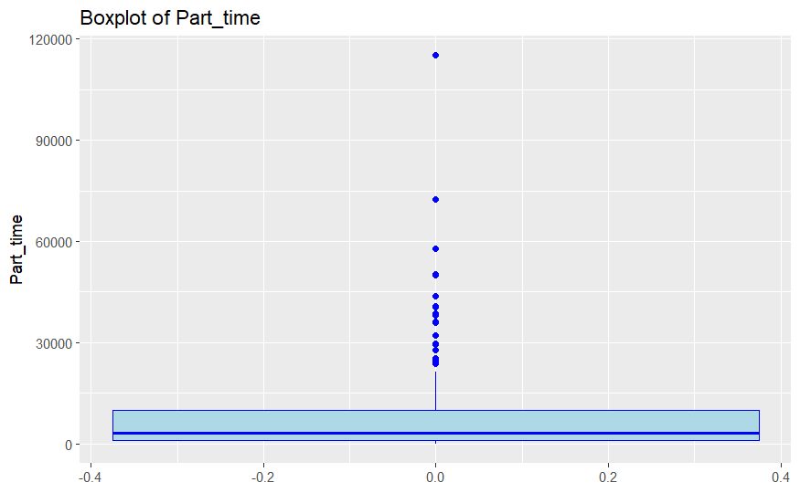

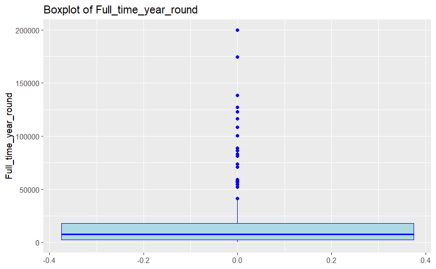

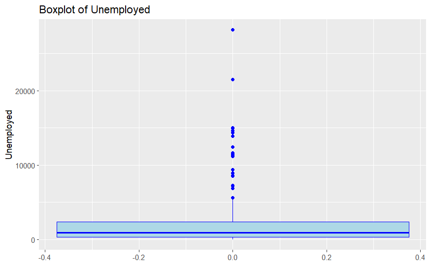

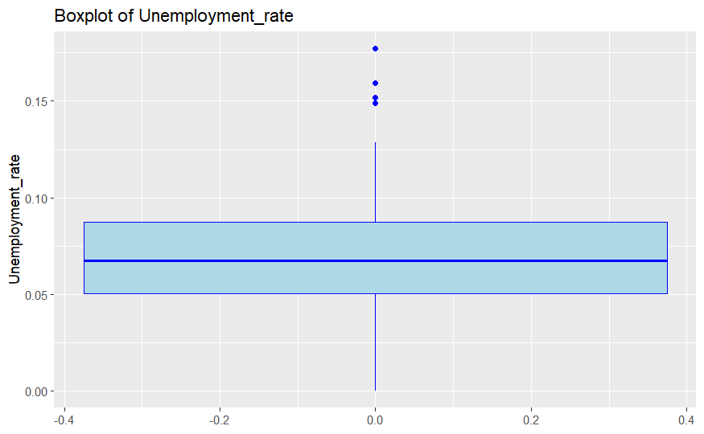

[6 more figures not shown]

```r
for ( var in colnames( select_if(df.clean, is.numeric) ) ) {
    g = ggplot(df.clean) +
        geom_boxplot( aes( y = unlist(df.clean[, var]) ),
                      fill = "lightblue", color = "blue") +
        labs(title = paste("Boxplot of", var),
             y = var)
    plot(g)
}
```

We can add a QQ plot as a visual indication of normality.